# Chapter One: AI Foundations

## Section 1.2 Traditional Artificial Intelligence

### Readings:

- Text, Chapter One, *AI Foundations*
- *Introduction to Artificial Intelligence* [Link to the article](https://www.red-gate.com/simple-talk/development/data-science-development/introduction-to-artificial-intelligence/)

**First things first: Attendance**

You will find the Attendance Sheet on your Brightspace Content Page. Please follow the link and enter the passphrase of the day!

Link: [Attendance Form](https://forms.office.com/r/Ase8YkHC9z)

### Accessing Brightspace

[brightspace.albany.edu](https://brighspace.albany.edu)

### Origins

McCullough and Pitts

1943

The mind (brain?) as a mechanism

Forms the basis of much of modern machine learning.

Similar to Wiener's ideas underlying *Cybernetics*

### Origins

Alan Turing

- The Turing Machine (1936) - the conceptual basis for all modern computing
- The Turing Test - Determine if an agent is an AI or a human
- World War Two Cyrptanalysis - Enigma - the decoding of Nazi military codes
- The human side of Alan Turing

[figure not shown]

### Origins

The Chinese Room

- John Searle
- 1980
- Doing an intelligent task by rote

[figure not shown]

**Strong AI [actual understanding]** VS **Weak AI [not actual understanding]**

Whatever those are?

Wozniak's Coffee Test "A machine is required to enter an average American home and figure out how to make coffee: find the coffee machine, find the coffee, add water, find a mug, and brew the coffee by pushing the proper buttons." ~(Wikipedia)

**Situated AI**

The founding fathers:

**Claude Shannon**

Cryptography, AI Games

**John von Neumann**

Modern computer architecture, game theory

**John McCarthy**

AI programming, early research, robotics

**Alan Newell, Herbert Simon**

Logic based AI

**Marvin Minsky**

Structure of AI programs. Pointed out problems in early machine learning.

Most of this early work was at universities or otherwise government funded. Industry wasn't much interested in AI in the 1950s-1960s.

Early efforts

**SAINT**

Symbolic logic for calculs problems

**ANALOGY**

Solve analogical reasoning problems

**STUDENT**

*Natural Language Processing* - solved High School Word Problems

**ELIZA**

A simulated Rogerian psychological analyst. One of the first hyped AI programs.

**Computer Vision**

Sussman's work in Minskys's lab at MIT to analysie images.

**Mac Hack**

Greenblatt's chess program. Achieved good but not great results.

**Hearsay I**

A continuous speech recognition system.

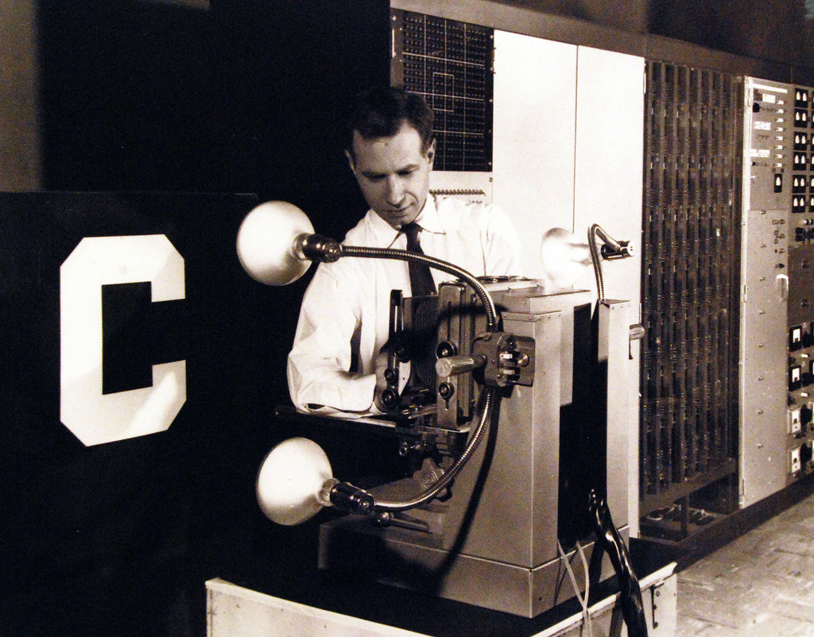

### Foreshadowing the Future (or at least the present)

ROsenblatt's Perceptron

1957

The model was built to be similar to actual neurons

Albeit greatly simplified.

### The Perceptron architecture:

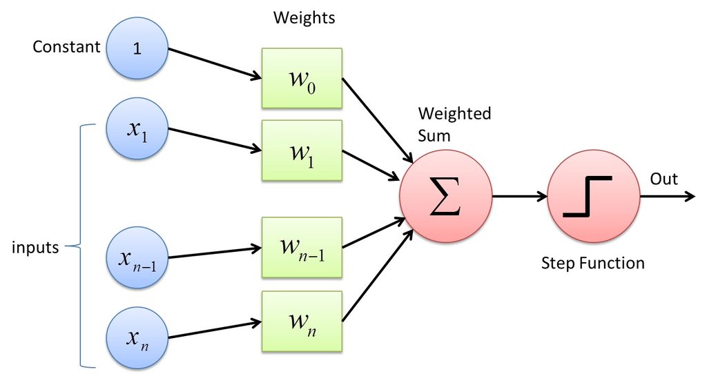

(Go over the Perceptron)

Positive and negative weights

The input as image pixels

In 1957, this was all done by hand wired electronics:

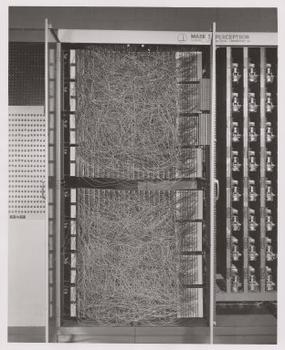

But, the Perceptron had limitations

- The lack of computing power at the time and the generally limited state of digital electronics.
- There were certain types of problems - non-linearly separable - that you could prove it couldn't solve.

In their 1969 book, *Perceptrons*, Minsky and Seymour Papert pointed out these problems.

This effectively killed work on Perceptrons, and all types of artificial neural network models until the mid 1980s.

### AI Winter

cf. Nuclear Winter

[figure not shown]

Image from: https://www.actuaries.digital/2018/09/05/history-of-ai-winters/

### Expert Systems

Rule based computer program that tried to capture and use human expertise on tasks.

They could work well - e.g. IBM's Deep Blue system that in 1996 defeated the world champion Gary Kasparov in chess.

They had significant shortcomings:

- They had to be created by hand. Every case, every scenario, every contingency had to be manually coded into them.
- This made them narrow in scope, and often brittle.
- They did not scale well.

### Neural Networks and Deep Learning

In the 1980s, several researchers revived and revised an *artificial neural networks* (ANN) style of AI.

One that was centered on *machine learning*(ML).

Weaknesses of early ANN models:

- Lack of computing power
- Inability to learn and/or represent certain classes of problems.

By the mid 1980s, solutions were forthcoming for both of these problems.

With the advent of seminconductors (basically computers and related electronics on chips) *Moore's Law* was observed. That is, every 18 months the number of transistors that could be put on a computer (memory, etc.) chip doubled.

This results in increased speed and computing power for chip based computers. This took care of the first problem (and still is...)

in 1986, David Rumlhart, Geoffrey Hinton, and Ronald Williams published their work on *error backpropagation*. This was a generalization of the way that the Perceptron worked. But, it could deal with much more complex classes of problems.

Within a few years, backpropagation-based machine learning systems had become the dominant model in AI. And have remained so ever since.

Other trend and discoveries from around the same time have led us to the modern main trends in machine learning.

- Kunihiko discovered pattern recognition techniques that became the basis for *convolutional neural networks* (CNN).
- John Hopfield laid the basis for *recurrent neural networks* - networks that can handle sequences of data (e.g. a series of images).
- Yann LeCun joined convolutional neural networks with backpropagation. This became the basis for modern *deep learning*.
- Later, LeCun made significant improvements into how the backpropogation algorithms work (added descent algorithms).
- Slightly different, but becoming increasingly important, Christopher Watkins, invented *Q-Learning*. This was an important foundation for *reinforcement learning*. In recent years, similar to LeCun's merger of backpropogation with CNNs to create deep learning, deep learning is merging with reinforcement learning to create *Deep Reinforcement Learning* to help solve additional types of problems.

### Factors Contributing to AI/ML today

In addition to the algorithms, several things are contributing to the popularity/utility of AI/ML today.

- Data - these machine learning models need data to learn from. The near universal use of computers (and data gaterhing sensors like cameras) provides this necessary data.
- Lots of fast computers, storage capacity, and high-speed networks. The infrastructure that holds this all together.
- GPUs - graphics processing units. These were originally were created to render computer graphics in video games. but, these same calculations, and the ability to do them *in parallel* make them also useful for AI/ML learning and calculations. (And for crypto mining, but that's a different story...)

## Team Exercise

In the Introduction, the author gives two examples of companies that use AI/ML, Uber and McDonalds. Starting from what Taulli says, discuss the following:

The two cases seem to be different uses of AI/ML technology. Examine the two cases, starting with Taulli, but searching the web as necessary (cite your sources you use!). Answer the following questions as best you can:

- Describe the two AI/ML use cases.
- What do they have in common?
- How are they different?
- Is one or the other more of an actual "artificial intelligence" application? Or are both? Neither?

For each of these justify your answer. Please submit on Brightspace:

- The names of the team members
- Your answers to the above.

### Preparing for Upcoming Classes

#### For next class:

- Read Chapter Three in the Text
- There will be a short quiz on Chapter Three.
  - (Individual and team)
- And team exercises.